# MODUL 3, Penggunaan Rmarkdown dan Koneksi ke R Pubs

Achmad Solikhin

2026-04-09

Untuk menggunakan syntax R diperlukan chunk yang ditandai dengan “`{r}`” sama hal nya dengan penggunaaan library, juga diperlukan chunk untuk mengakses library tertentu.

```r
# Memuat paket yang diperlukan untuk koneksi database dan visualisasi
library(DBI)
library(ggplot2)
library(scales)
```

# Pendahuluan

Laporan ini menyajikan banyaknya item untuk tiap product scale dari database “classicmodels”. Proses ini mengintegrasikan SQL untuk pengambilan data dan R untuk visualisasi.

# Koneksi Database dan Pengambilan Data

Langkah pertama adalah membangun koneksi antara RStudio dan database MySQL menggunakan fungsi dbConnect()

```r
con <- DBI::dbConnect(odbc::odbc(),

                          Driver = "MySQL ODBC 8.0 ANSI Driver",
                          Server = "127.0.0.1",
                          Database = "classicmodels",
                          UID = "root",
                          PWD = "080391",
                          Port = 3306)
```

Setelah koneksi terjalin, kita menggunakan blok kode SQL untuk mendapatkan banyaknya item untuk tiap product scale. Simpan data hasil kueri data dalam suatu data frame R.

```r
# Mendapatkan data yang diperlukan
data1 <- dbGetQuery(con, "SELECT productScale,
                  COUNT(*) AS totalItems
                  FROM products
                  GROUP BY productScale")

data1
```

```
##   productScale totalItems
## 1         1:10          6
## 2         1:12          9
## 3         1:18         42
## 4         1:72          4
## 5         1:24         27
## 6         1:32          8
## 7         1:50          4
## 8        1:700         10
```

# Visualisasi banyaknya item tiap product scale

Kita menggunakan library ggplot2 untuk membuat barchart. Fungsi geom_bar() digunakan untuk melihat banyaknya item tiap product scale.

```
## Defaulting to continuous.
```

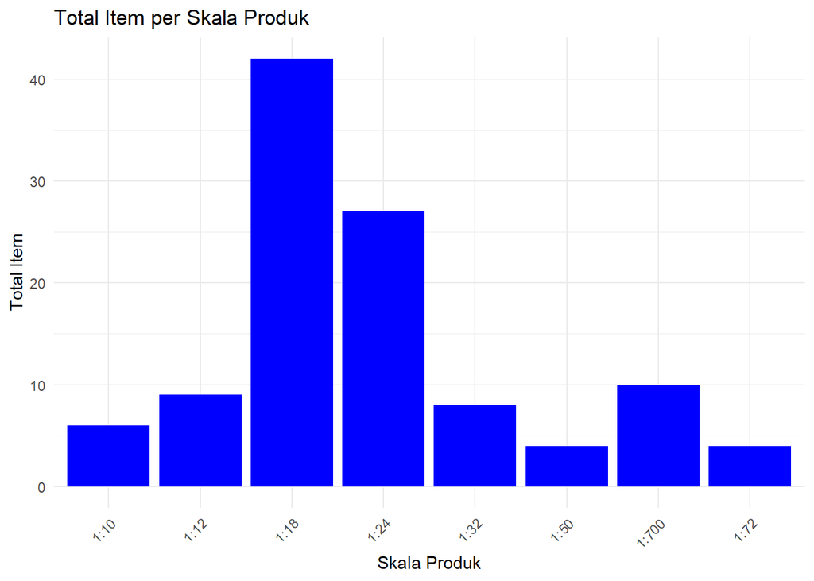

```r
# Membuat barchart untuk banyaknya item tiap product scale

ggplot(data1, aes(x = productScale, y = totalItems)) +
  geom_bar(stat = "identity", fill = "blue", alpha = 1) +
  theme_minimal() +
  labs(title = "Total Item per Skala Produk",
       x = "Skala Produk",
       y = "Total Item") +
  theme(axis.text.x = element_text(angle = 45, hjust = 1))
```

# Latihan

buat sebuah histogram dengan label yang sesuai untuk nilai (value) dari orders yang diterima dari negara-negara Nordic (Denmark, Finland, Norway, Sweden)! Tahap pertama kali yang dilakukan adalah menggunakan library(BDI) guna menghubungkan data dari MySQL dengan R

```r
conn<- DBI::dbConnect(odbc::odbc(),

                          Driver = "MySQL ODBC 8.0 ANSI Driver",
                          Server = "127.0.0.1",
                          Database = "classicmodels",
                          UID = "root",
                          PWD = "080391",
                          Port = 3306)
```

```r
data<-dbGetQuery(conn,"select c.country, sum(od.quantityOrdered) as jumlah
from orderdetails od
join orders o on od.ordernumber=o.ordernumber
join customers c on o.customerNumber=c.customerNumber
where c.country in ('Denmark', 'Finland', 'Norway', 'Sweden')
group by c.country;")
jumlah<-data$jumlah
```

Kemudian akan dibuat sebuah grafik histogram untuk memvisualisasikan data order tiap negara nordik

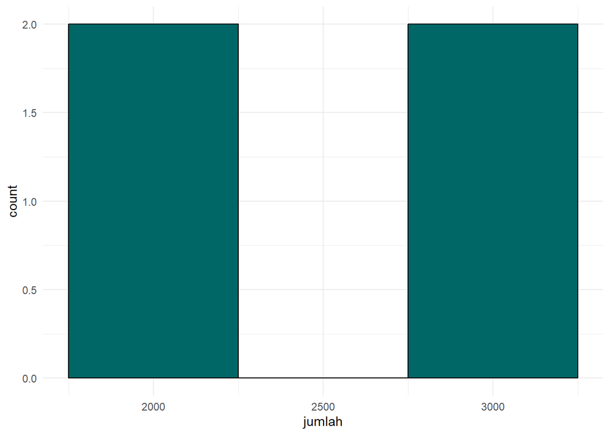

```r
grafik<-ggplot(data.frame(jumlah),aes(x=jumlah))+geom_histogram(binwidth = 500,fill="#066",color="black")+theme_minimal()
grafik
```

kemudian buat grafik bar chart untuk visualisasi kedua

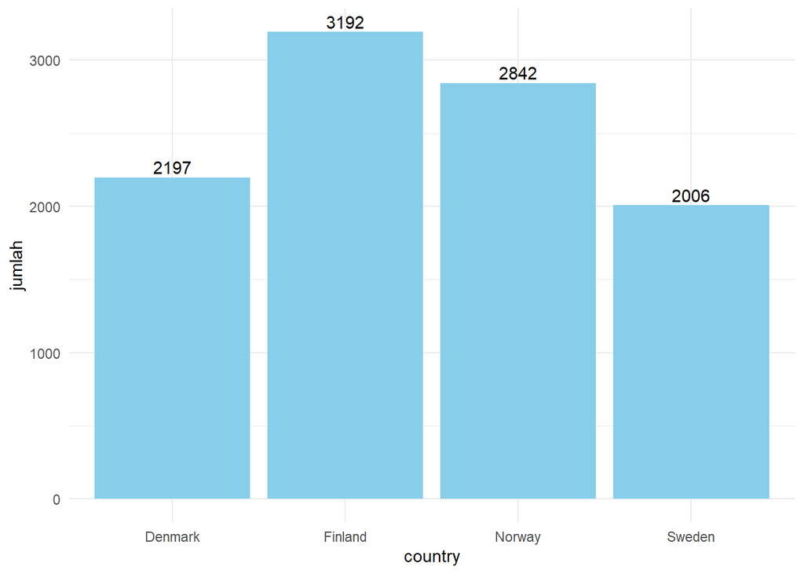

```r
grafik1<-ggplot(data,aes(x=country,y=jumlah))+geom_bar(stat="identity",fill="skyblue")+geom_text(aes(label = jumlah),vjust= -0.3)+theme_minimal()
grafik1
```